# RWA Assignment - 2

Q1 Reading the data

```r
the.data <- as.matrix(read.table("ENB_2023.txt"))
```

Setting the seed for replication

```r
set.seed(223602808)
```

Taking only certain rows

```r
my.data <- the.data[sample(1:671,340),c(1:6)]
```

```r
backup_data<-my.data
```

Plotting Scatter Plots

```r
par(mfrow=c(2,3))
```

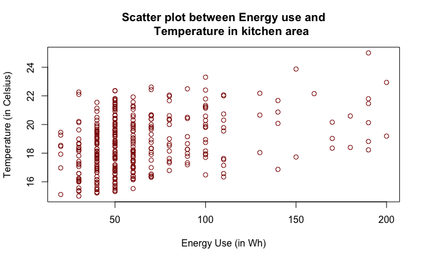

```r
plot(my.data[,6], my.data[,1], main="Scatter plot between Energy use and
     Temperature in kitchen area", xlab="Energy Use (in Wh)",
     ylab="Temperature (in Celsius)", col=" dark red")
```

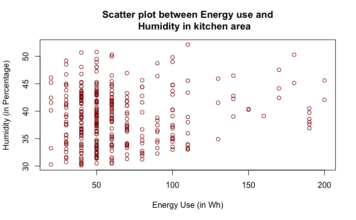

```r
plot(my.data[,6], my.data[,2], main="Scatter plot between Energy use and
     Humidity in kitchen area", xlab="Energy Use (in Wh)",
     ylab="Humidity (in Percentage)", col="dark red")
```

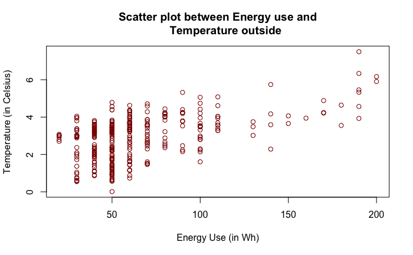

```r
plot(my.data[,6], my.data[,3], main="Scatter plot between Energy use and
     Temperature outside", xlab="Energy Use (in Wh)",
     ylab="Temperature (in Celsius)", col="dark red")
```

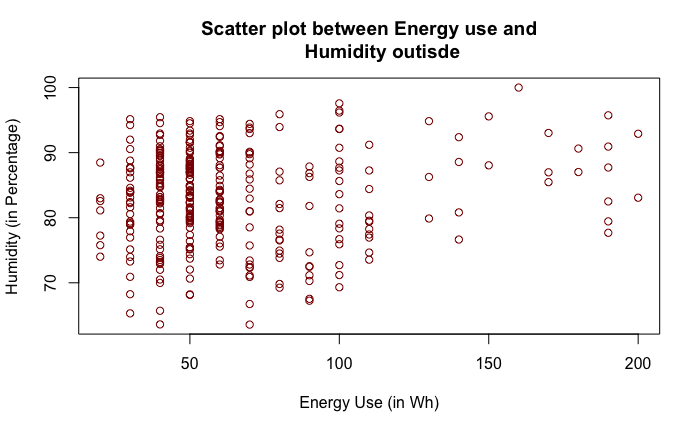

```r
plot(my.data[,6], my.data[,4], main="Scatter plot between Energy use and
     Humidity outisde", xlab="Energy Use (in Wh)",
     ylab="Humidity (in Percentage)", col="dark red")
```

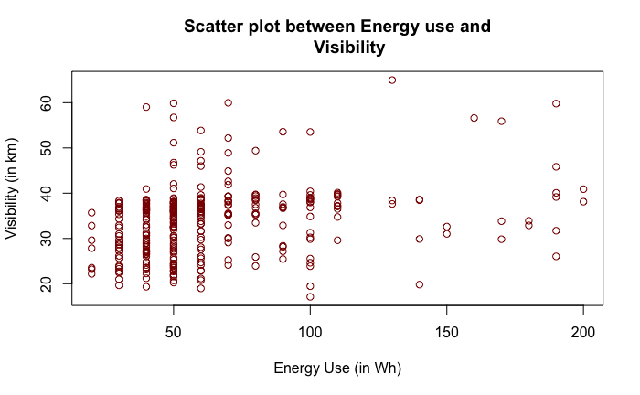

```r
plot(my.data[,6], my.data[,5], main="Scatter plot between Energy use and
     Visibility", xlab="Energy Use (in Wh)",
     ylab="Visibility (in km)", col="dark red")
```

Importing library

```r
library(rcompanion)
```

Plotting Histogram

```r
par(mfrow=c(2,3))
```

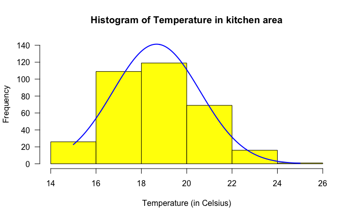

```r
plotNormalHistogram(my.data[,1], main = "Histogram of Temperature in kitchen area", xlab= "Temperature (in Celsius)", breaks=5, las=1, xlim=c(14,26), col="yellow")
```

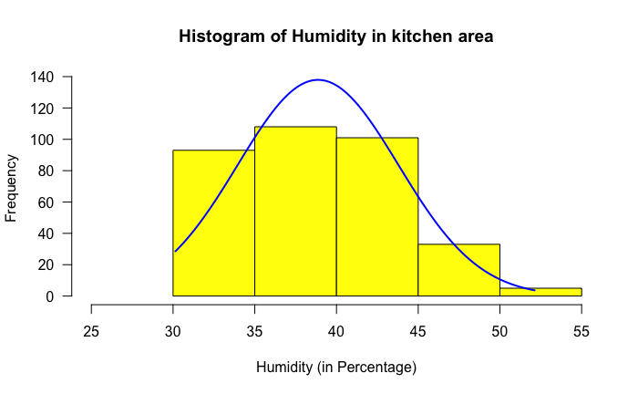

```r
plotNormalHistogram(my.data[,2], main = "Histogram of Humidity in kitchen area", xlab= "Humidity (in Percentage)", breaks=5, las=1, xlim=c(25,55), col="yellow")
```

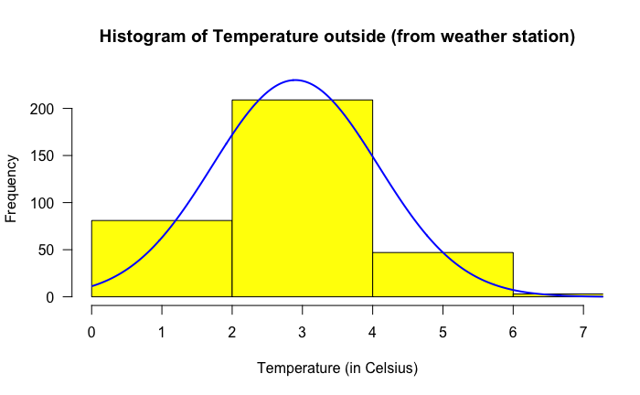

```r
plotNormalHistogram(my.data[,3], main = "Histogram of Temperature outside (from weather station)", xlab= "Temperature (in Celsius)", breaks=5, las=1, xlim=c(0,7),col="yellow")
```

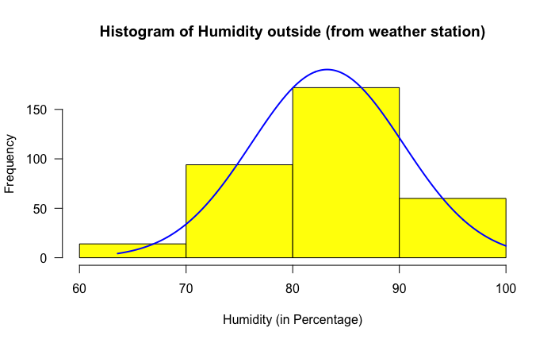

```r
plotNormalHistogram(my.data[,4], main = "Histogram of Humidity outside (from weather station)", xlab= "Humidity (in Percentage)", breaks=5, las=1, xlim=c(60,100),col="yellow")
```

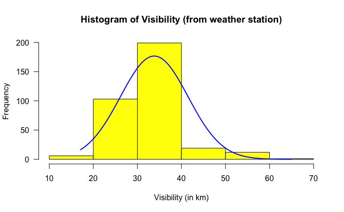

```r
plotNormalHistogram(my.data[,5], main = "Histogram of Visibility (from weather station)", xlab= "Visibility (in km)", breaks=5, las=1, xlim=c(10,70), col="yellow")
```

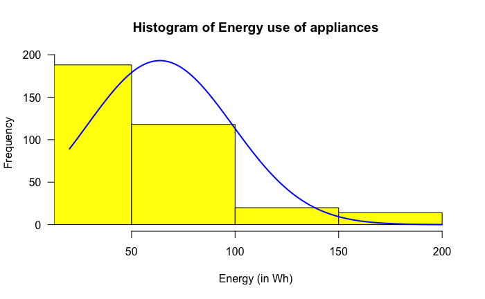

```r
plotNormalHistogram(my.data[,6], main = "Histogram of Energy use of appliances", xlab= "Energy (in Wh)", breaks=5, las=1,xlim=c(20,200),col="yellow")
```

```r
for( i in 1:6) {
  pvalue_variables<-ks.test(jitter(my.data[,i]), "pnorm", mean=mean(my.data[,i]), sd=sd(my.data[,i]))
  print(pvalue_variables)
}
```

```
    Asymptotic one-sample Kolmogorov-Smirnov test

data:  jitter(my.data[, i])
D = 0.046138, p-value = 0.4642
alternative hypothesis: two-sided


    Asymptotic one-sample Kolmogorov-Smirnov test

data:  jitter(my.data[, i])
D = 0.0619, p-value = 0.1477
alternative hypothesis: two-sided


    Asymptotic one-sample Kolmogorov-Smirnov test

data:  jitter(my.data[, i])
D = 0.091163, p-value = 0.007026
alternative hypothesis: two-sided


    Asymptotic one-sample Kolmogorov-Smirnov test

data:  jitter(my.data[, i])
D = 0.070727, p-value = 0.06664
alternative hypothesis: two-sided


    Asymptotic one-sample Kolmogorov-Smirnov test

data:  jitter(my.data[, i])
D = 0.12426, p-value = 5.509e-05
alternative hypothesis: two-sided


    Asymptotic one-sample Kolmogorov-Smirnov test

data:  jitter(my.data[, i])
D = 0.21327, p-value = 7.383e-14
alternative hypothesis: two-sided
```

KS - Test Result X1 P-value = 0.4642 X2 P-value = 0.1477 X3 P-value = 0.007026 X4 P-value = 0.06664 X5 P-value = 5.509e-05 Y P-value = 7.383e-14

Since p-value for X1, X2, X4 is > 0.05, there is no significant difference between normal distribution and distribution of variables. Hence leaving the data untransformed.

Also, X3, X5 and Y are not normally distributed as per the KS - test, we need to check for skewness and apply transformation accordingly.

If Skewness is 0, then it means to be a perfect normal distribution If Skewness is between -0.5 and 0.5, we can approximate it to a normal distribution If Skewness is > 0.5, it is positively Skewed If Skewness is <-0.5, it is negatively Skewed

Importing moments library for finding skewness

```r
library(moments)
```

Finding skewness for X3

```r
print(skewness(my.data[,3]))
```

```
[1] 0.01446961
```

Finding skewness for X5

```r
print(skewness(my.data[,5]))
```

```
[1] 0.7299919
```

Finding skewness for Y

```r
print(skewness(my.data[,6]))
```

```
[1] 1.917926
```

Skewness: X3 = 0.01446961 X5 = 0.7299919 Y = 1.917926

Since Skewness X3 is very close 0, we can ignore performing any transformation to it.

Since X5 and Y is > 0.5, they are positively Skewed. Hence we will apply log transformation on X5 and Y.

```r
pearson_results<-array(0,5)
```

```r
for(i in 1:5){
  pearson_results[i]<-cor(my.data[,6], my.data[,i])
}
```

```r
pearson_results
```

```
[1] 0.34019074 0.10402363 0.50893775 0.08549348 0.26904480
```

```r
spearman_results<-array(0,5)
```

```r
for(i in 1:5){
  spearman_results[i]<-cor(my.data[,6], my.data[,i])
}
```

```r
spearman_results
```

```
[1] 0.34019074 0.10402363 0.50893775 0.08549348 0.26904480
```

Applying log transformation on X5 and Y Creating the log function

```r
log.fun<-function(x){
  result=log10(x)
  return(result)
}
```

Applying log on X5

```r
my.data[,5] <- log.fun(my.data[,5])
```

```r
log.transform.5 <- my.data[,5]
```

```r
log.transform.5
```

```
  [1] 1.611633 1.557511 1.459569 1.585989 1.380233 1.493864 1.334957 1.708903 1.408078 1.578459 1.564808 1.566613 1.588280 1.566012
 [15] 1.569605 1.525585 1.454039 1.557511 1.501292 1.470194 1.546080 1.584263 1.589421 1.558124 1.581371 1.577289 1.556898 1.571984
 [29] 1.513269 1.544314 1.582530 1.409115 1.356327 1.552578 1.562389 1.391504 1.599000 1.545079 1.776709 1.547211 1.509998 1.566613
 [43] 1.582530 1.558124 1.771121 1.326481 1.503808 1.563842 1.571390 1.579043 1.487825 1.594519 1.578459 1.563600 1.438958 1.395048
 [57] 1.448378 1.532750 1.669809 1.556283 1.549176 1.518130 1.484935 1.652230 1.442169 1.432302 1.521945 1.378366 1.423649 1.500174
 [71] 1.661202 1.569008 1.812913 1.574349 1.581371 1.567812 1.355938 1.388437 1.289003 1.691476 1.559786 1.520807 1.379661 1.613361
 [85] 1.472154 1.673560 1.558124 1.493719 1.546882 1.594519 1.559347 1.542413 1.461103 1.440319 1.577874 1.477088 1.629808 1.562620
 [99] 1.325226 1.359821 1.548355 1.586563 1.600113 1.233228 1.752975 1.598442 1.516456 1.378922 1.559957 1.471598 1.585989 1.335227
[113] 1.479099 1.566971 1.415624 1.433781 1.431748 1.370327 1.462662 1.584263 1.584839 1.382423 1.580790 1.471242 1.373148 1.554435
[127] 1.579043 1.485804 1.495208 1.444686 1.561175 1.555914 1.449465 1.414889 1.576702 1.517054 1.551244 1.623698 1.579626 1.576115
[141] 1.317197 1.475411 1.538295 1.731169 1.535724 1.548215 1.570796 1.392760 1.363671 1.375019 1.616572 1.602884 1.585415 1.474966
[155] 1.367160 1.417659 1.402331 1.509998 1.377810 1.563600 1.565410 1.569008 1.554548 1.565410 1.479128 1.452911 1.387531 1.576702
[169] 1.665240 1.728943 1.435025 1.594519 1.512010 1.584263 1.432256 1.562389 1.584263 1.566012 1.465117 1.423606 1.589990 1.552072
[183] 1.585989 1.513540 1.512861 1.435383 1.550327 1.485515 1.384254 1.579626 1.486382 1.371834 1.753912 1.603436 1.447067 1.481019
[197] 1.456949 1.474669 1.597884 1.569008 1.592826 1.542103 1.777917 1.413408 1.580790 1.403032 1.321864 1.693756 1.463850 1.552206
[211] 1.551957 1.546294 1.561175 1.573168 1.461868 1.589990 1.480712 1.512508 1.480595 1.568329 1.568410 1.606514 1.717556 1.393637
[225] 1.365392 1.425258 1.527034 1.574939 1.511636 1.563518 1.538295 1.593391 1.360015 1.471144 1.405649 1.587708 1.524528 1.293080
[239] 1.372210 1.494202 1.491404 1.598442 1.500174 1.573759 1.341660 1.595081 1.622067 1.358334 1.588851 1.446827 1.529207 1.586792
[253] 1.453690 1.564325 1.517054 1.430156 1.407385 1.599025 1.382423 1.443887 1.562389 1.591127 1.341660 1.515220 1.551957 1.728528
[267] 1.382423 1.576115 1.547713 1.528977 1.570796 1.532914 1.611981 1.530311 1.351033 1.747465 1.573168 1.584263 1.575528 1.360594
[281] 1.564204 1.473183 1.590559 1.464610 1.570201 1.564204 1.540874 1.345750 1.513676 1.434055 1.662743 1.316343 1.278173 1.581208
[295] 1.576115 1.777153 1.347670 1.569605 1.306400 1.551167 1.583686 1.511091 1.522405 1.535646 1.569008 1.597884 1.584839 1.296753
[309] 1.448205 1.575520 1.538894 1.517027 1.564808 1.570796 1.542258 1.435503 1.561175 1.595081 1.372022 1.435886 1.491552 1.689425
[323] 1.286263 1.567812 1.587136 1.558736 1.410971 1.565410 1.477105 1.458030 1.470650 1.427531 1.574184 1.519203 1.537433 1.586563
[337] 1.562389 1.577874 1.556898 1.415454
```

Applying log on Y

```r
my.data[,6] <- log.fun(my.data[,6])
```

```r
log.transform.Y <- my.data[,6]
```

```r
log.transform.Y
```

```
  [1] 2.301030 1.602060 1.698970 1.602060 1.698970 1.602060 1.698970 1.698970 1.778151 1.477121 1.602060 1.602060 1.698970 1.778151
 [15] 1.778151 1.698970 1.698970 1.602060 2.278754 1.602060 1.845098 1.845098 2.000000 1.698970 1.698970 1.602060 1.778151 1.845098
 [29] 1.698970 1.698970 1.845098 1.477121 1.477121 1.301030 1.477121 2.000000 1.954243 1.778151 2.278754 1.845098 1.698970 2.000000
 [43] 1.602060 1.698970 1.602060 1.602060 1.698970 1.477121 1.778151 2.000000 1.602060 1.845098 1.477121 1.698970 1.602060 1.602060
 [57] 1.602060 1.602060 1.698970 1.698970 1.845098 1.845098 1.477121 1.845098 1.698970 1.602060 1.698970 1.698970 1.602060 1.778151
 [71] 2.278754 1.698970 2.113943 1.903090 1.698970 1.477121 1.698970 1.698970 2.000000 1.778151 1.698970 1.778151 1.477121 1.698970
 [85] 1.477121 1.778151 1.698970 1.602060 1.903090 1.845098 1.602060 1.602060 1.602060 1.778151 1.698970 1.845098 1.845098 2.041393
 [99] 1.778151 1.778151 1.903090 1.903090 2.041393 2.000000 2.204120 2.041393 1.301030 1.903090 1.698970 1.301030 1.602060 1.698970
[113] 1.845098 1.778151 2.278754 1.602060 1.698970 1.698970 1.602060 1.602060 1.903090 1.602060 2.000000 2.041393 1.698970 1.698970
[127] 1.602060 1.698970 2.000000 1.301030 1.602060 1.698970 1.954243 1.602060 1.477121 1.477121 1.903090 1.698970 1.698970 1.698970
[141] 1.778151 2.146128 1.698970 1.778151 1.602060 1.477121 1.698970 1.778151 1.602060 1.477121 1.778151 2.278754 1.778151 2.000000
[155] 1.477121 1.477121 1.845098 1.698970 2.000000 1.698970 1.903090 2.041393 1.778151 1.698970 1.698970 1.954243 1.698970 1.778151
[169] 1.698970 1.954243 1.602060 1.845098 1.602060 1.602060 1.602060 1.778151 1.602060 1.954243 1.477121 1.602060 1.903090 1.698970
[183] 2.000000 2.176091 1.698970 1.602060 1.778151 1.698970 1.698970 1.698970 1.602060 1.301030 1.698970 2.041393 1.477121 1.778151
[197] 1.477121 2.230449 2.000000 1.698970 2.278754 1.698970 1.845098 1.903090 1.845098 1.698970 1.477121 1.903090 1.845098 1.698970
[211] 1.602060 1.845098 1.602060 1.778151 1.602060 1.698970 1.698970 1.602060 2.000000 1.778151 1.602060 2.000000 1.845098 1.602060
[225] 1.301030 1.602060 1.698970 1.954243 1.698970 1.602060 1.698970 2.041393 1.698970 1.698970 1.954243 2.000000 1.903090 1.477121
[239] 1.602060 1.602060 1.477121 1.903090 1.778151 1.602060 1.698970 1.903090 1.845098 1.778151 1.778151 1.698970 2.230449 1.778151
[253] 1.602060 1.954243 1.954243 1.602060 2.000000 1.903090 1.778151 1.477121 1.778151 2.000000 1.698970 1.698970 1.602060 2.000000
[267] 1.845098 1.698970 1.698970 1.778151 1.698970 1.698970 1.602060 2.255273 1.477121 2.230449 1.778151 2.113943 1.602060 1.698970
[281] 1.778151 1.778151 1.778151 1.477121 1.602060 1.778151 2.041393 1.301030 1.698970 1.954243 1.778151 1.698970 1.778151 2.301030
[295] 1.698970 1.698970 1.602060 1.778151 1.698970 1.845098 1.477121 1.477121 1.778151 1.477121 1.698970 1.778151 2.146128 2.146128
[309] 1.778151 2.113943 1.778151 2.255273 1.602060 2.041393 2.000000 1.477121 1.602060 2.041393 1.602060 1.698970 2.176091 1.845098
[323] 1.602060 1.954243 1.778151 1.477121 1.698970 1.698970 1.602060 1.477121 1.602060 1.698970 1.845098 1.602060 1.698970 2.146128
[337] 1.778151 2.041393 1.477121 1.778151
```

Applying min-max

```r
minmax<-function(x){
  result=(x-min(x))/(max(x)-min(x))
  return(result)
}
```

```r
my.data[,1] <- minmax(my.data[,1])
```

```r
my.data[,2] <- minmax(my.data[,2])
```

```r
my.data[,2]
```

[output not shown]

```r
my.data[,3] <- minmax(my.data[,3])
```

```r
my.data[,4] <- minmax(my.data[,4])
```

```r
my.data[,5] <- minmax(my.data[,5])
```

```r
my.data[,6] <- minmax(my.data[,6])
```

```r
par(mfrow=c(2,3))
```

[figure not shown]

```r
plotNormalHistogram(my.data[,1], main = "Histogram of Humidity in kitchen area after Min-Max transformation", xlab= "Humidity (in Percentage)", las=1,col="green")
```

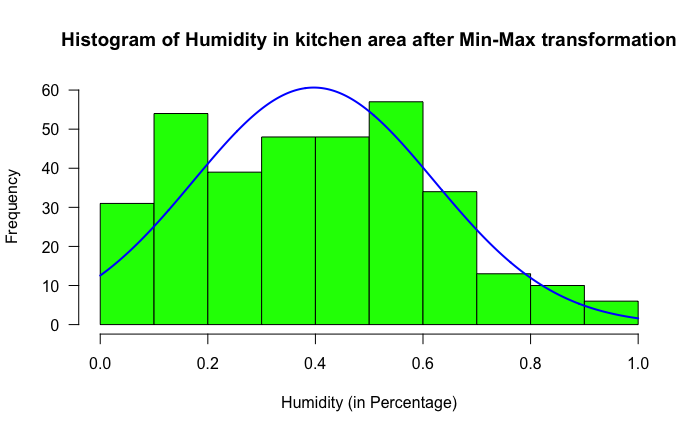

```r
plotNormalHistogram(my.data[,2], main = "Histogram of Humidity in kitchen area after Min-Max transformation", xlab= "Humidity (in Percentage)", las=1,col="green")
```

[figure not shown]

```r
plotNormalHistogram(my.data[,3], main = "Histogram of Humidity in kitchen area after Min-Max transformation", xlab= "Humidity (in Percentage)", las=1,col="green")
```

[figure not shown]

```r
plotNormalHistogram(my.data[,5], main = "Histogram of Humidity in kitchen area after Min-Max transformation", xlab= "Humidity (in Percentage)", las=1,col="green")
```

[figure not shown]

```r
plotNormalHistogram(my.data[,6], main = "Histogram of Humidity in kitchen area after Min-Max transformation", xlab= "Humidity (in Percentage)", las=1,col="green")
```

Since we do not need X4 we can remove that feature

```r
my.data<-my.data[,-4]
```

Verifying the data

```r
View(my.data)
```

Writing the data to another file

```r
write.table(my.data, "likith_transformed_sample.txt")
```

Importing AggWaFit.R

```r
source("AggWaFit718.R")
```

Reading the data and converting it to a matrix for manipulation

```r
transformed.data<-as.matrix(read.table("likith_transformed_sample.txt"))
```

```r
View(transformed.data)
```

Building Models weights for Weighted Arithmetic Mean with fit.QAM()

```r
fit.QAM(transformed.data,"out_AM.txt","stat_AM.txt",g=AM,g.inv=invAM)
```

RMSE 0.167044631433746 Av. abs error 0.128133480607362 Pearson correlation 0.589251762910605 Spearman correlation 0.543675440205338

weights for Power Mean p=0.5 with fit.QAM()

```r
fit.QAM(transformed.data,"out_PM05.txt","stat_PM05.txt",g=PM05,g.inv=invPM05)
```

RMSE 0.172205586055085 Av. abs error 0.131275041599399 Pearson correlation 0.56413850037432 Spearman correlation 0.529207819083485

weights for Power Mean p=2 with fit.QAM()

```r
fit.QAM(transformed.data,"out_QM.txt","stat_QM.txt",g=QM,g.inv=invQM)
```

RMSE 0.162658294298987 Av. abs error 0.125277679913978 Pearson correlation 0.607491775262898 Spearman correlation 0.558280759785093

weights for Ordered Weighted Average with fit.OWA()

```r
fit.OWA(transformed.data,"out_OWA.txt","stat_OWA.txt")
```

RMSE 0.178060803916844 Av. abs error 0.139440884735571 Pearson correlation 0.473244183224705 Spearman correlation 0.423779691018706 Orness 0.570405825156529

weights for Choquet Integral with fit.choquet()

```r
fit.choquet(transformed.data,"out_choq.txt","stat_choq.txt")
```

RMSE 0.156912634794026 Av. abs error 0.121800581867797 Pearson Correlation 0.631595637242979 Spearman Correlation 0.582679534069074 Orness 0.643574950868064

Using model for prediction Since we can see that the choquet provides the lowest RMSE and Av. abs error, we can select choquet model for prediction X1=22; X2=38; X3=4; X4=88.2; X5=34

Selecting only X1, X2, X3 and X5 because we trained the model with these features

```r
new.data <- c(22,38,4,34)
```

```r
transform.new.data<-new.data
```

Transforming the new data Since we did not apply any transformation for X1, X2 and X3 features, we are also not going to apply any transformation for the new data min-maxing X1

```r
transform.new.data[1]<-(new.data[1]-min(backup_data[,1]))/(max(backup_data[,1])-min(backup_data[,1]))
```

min-maxing X2

```r
transform.new.data[2]<-(new.data[2]-min(backup_data[,2]))/(max(backup_data[,2])-min(backup_data[,2]))
```

min-maxing X3

```r
transform.new.data[3]<-(new.data[3]-min(backup_data[,3]))/(max(backup_data[,3])-min(backup_data[,3]))
```

Applying log, since we applied log transformation for X5

```r
transform.new.data[4]<-log.fun(new.data[4])
```

min-maxing X5

```r
transform.new.data[4]<-(transform.new.data[4]-min(log.transform.5))/(max(log.transform.5)-min(log.transform.5))
```

```r
transform.new.data
```

```
[1] 0.7000000 0.3573697 0.5326166 0.5145048
```

Taking the choquet weights from the stat_choq output file

```r
ChoqWeights <- c(0.54193303432683, 0, 0.54193303432683, 0.773863518370135, 0.999999999997865, 0.773863518370135, 0.999999999997865, 0.402146540858998, 0.541933034326625, 0.402146540858998, 0.541933034326625, 0.773863518370138, 0.999999999999115, 0.773863518370138, 0.999999999999115)
```

Prediction MAIN EVENT WRESTLEMANIA…!!!!!!!!!!!!!!!!!!!!!!!!!!!!!!!!!!!!!!!!!!!!!!

```r
result <- choquet(transform.new.data, ChoqWeights)
```

```r
result
```

```
[1] 0.6233272
```

Reversing the transformation

```r
transform.result<-result*(max(log.transform.Y)-min(log.transform.Y))+min(log.transform.Y)
```

```r
transform.result
```

```
[1] 1.924357
```

```r
predicted_output<-10^(transform.result)
```

```r
predicted_output
```

```
[1] 84.01507
```